# TidyFriday

# Popecol data viz using TidyTuesday datasets

[Google doc link](https://docs.google.com/document/d/1XWlxHSOURZ4dniOsA1lyoHDCHYhZrx5nvCuxFwkkcTA/edit#heading=h.nj23sjpj5u97)

## Loading packages

```r
library(tidyverse)
```

# Dog breeds dataset

Download data to RStudio environment:

```r
breed_traits = readr::read_csv ('https://raw.githubusercontent.com/rfordatascience/tidytuesday/master/data/2022/2022-02-01/breed_traits.csv')
trait_description = readr::read_csv ('https://raw.githubusercontent.com/rfordatascience/tidytuesday/master/data/2022/2022-02-01/trait_description.csv')
breed_rank_all = readr::read_csv ('https://raw.githubusercontent.com/rfordatascience/tidytuesday/master/data/2022/2022-02-01/breed_rank.csv')
```

## Spider/Radar plots

Plotting favorite dogs by country (Germany and Brazil) and their personality traits.

Selecting and renaming traits, and removing spaces from breed names.

```r
breed_traits <- breed_traits %>%
  select(Breed,
         `Affectionate With Family`,
         `Openness To Strangers`,
         `Good With Other Dogs`,
         `Playfulness Level`,
         `Trainability Level`,
         `Energy Level`,
         `Watchdog/Protective Nature`,
         `Barking Level`,
         `Mental Stimulation Needs`,
         `Shedding Level`,
         `Coat Grooming Frequency`) %>%
  rename("Family affection" = "Affectionate With Family",
         "Stranger friendliness" = "Openness To Strangers",
         "Dog friendliness" = "Good With Other Dogs",
         "Playfulness" = "Playfulness Level",
         "Trainability" = "Trainability Level",
         "Energy" = "Energy Level",
         "Protectivity" = "Watchdog/Protective Nature",
         "Barking" = "Barking Level",
         "Play demand" = "Mental Stimulation Needs",
         "Shedding" = "Shedding Level",
         "Grooming demand" = "Coat Grooming Frequency") %>%
  mutate(Breed=str_squish(Breed))
```

Select top 10 favorite breeds in and turn breed into factor.

```r
german_favs <- breed_traits %>%
  filter(Breed %in% c("Pomeranians", "Boxers", "German Shepherd Dogs", "Rottweilers",
                      "Standard Schnauzers", "Miniature Pinschers", "Dachshunds",
                      "Great Danes", "Doberman Pinschers", "Weimaraners")) %>%
  mutate(Breed = factor(Breed))


brazilian_favs <- breed_traits %>%
  filter(Breed %in% c("Shih Tzu", "Yorkshire Terriers", "Poodles", "Lhasa Apsos",
                      "Bulldogs", "Dachshunds", "Maltese",
                      "Finnish Spitz", "Miniature Pinschers", "Standard Schnauzers"))%>%
  mutate(Breed = factor(Breed))
```

## Radar plot using ggradar

Install/load ggradar package.

```r
devtools::install_github("ricardo-bion/ggradar", dependencies = TRUE)
library(ggradar)
```

Plot of favorite dogs in Germany

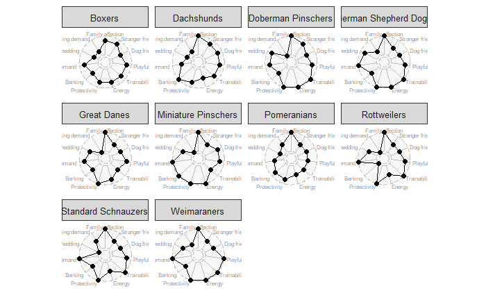

```r
german_favs %>%
ggradar(grid.min = 1,                    #minumum trait value
          grid.max = 5,                  #maximum trait value
          values.radar = c(1, 5),
          label.gridline.mid = FALSE,
          axis.label.size = 2,           # trait font size
          axis.label.offset = 1.1,       # trait name distance from the circle
          group.point.size = 2,          # trait value point size
          group.colours = "black",       # line color
          gridline.mid.colour = "gray",  # color of the central circle
          group.line.width = 0.5,        # line thickness
          grid.label.size = 0) +         # remove label
  facet_wrap(vars(group)) +              # separate plots by breed
  theme(legend.position = "none",        # remove legend
        strip.text = element_text(size = 10)) # breed name font size
```

Plot of favorite dogs in Brazil

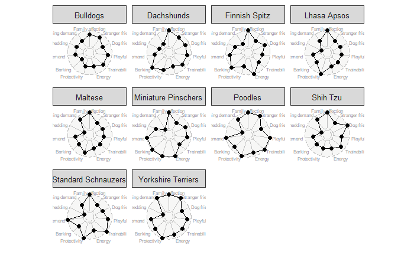

```r
brazilian_favs %>%
ggradar(grid.min = 1,                    #minumum trait value
          grid.max = 5,                  #maximum trait value
          values.radar = c(1, 5),
          label.gridline.mid = FALSE,
          axis.label.size = 2,           # trait font size
          axis.label.offset = 1.1,       # trait name distance from the circle
          group.point.size = 2,          # trait value point size
          group.colours = "black",       # line color
          gridline.mid.colour = "gray",  # color of the central circle
          group.line.width = 0.5,        # line thickness
          grid.label.size = 0) +         # remove label
  facet_wrap(vars(group)) +              # separate plots by breed
  theme(legend.position = "none",        # remove legend
        strip.text = element_text(size = 10)) # breed name font size
```

#### All options in ggradar

- ggradar(plot.data, base.size = 15,
- font.radar = “sans”,
- values.radar = c(“0%”, “50%”, “100%”),
- axis.labels = colnames(plot.data)[-1],
- grid.min = 0,
- grid.mid = 0.5,
- grid.max = 1,
- centre.y = grid.min - ((1/9) *(grid.max - grid.min)),*
- *plot.extent.x.sf = 1,*
- *plot.extent.y.sf = 1.2,*
- *x.centre.range = 0.02* (grid.max - centre.y),
- label.centre.y = FALSE,
- grid.line.width = 0.5,
- gridline.min.linetype = “longdash”,
- gridline.mid.linetype = “longdash”,
- gridline.max.linetype = “longdash”,
- gridline.min.colour = “grey”,
- gridline.mid.colour = “#007A87”,
- gridline.max.colour = “grey”,
- grid.label.size = 6,
- gridline.label.offset = -0.1 * (grid.max - centre.y),
- label.gridline.min = TRUE,
- label.gridline.mid = TRUE,
- label.gridline.max = TRUE,
- axis.label.offset = 1.15,
- axis.label.size = 5,
- axis.line.colour = “grey”,
- group.line.width = 1.5,
- group.point.size = 6,
- group.colours = NULL,
- background.circle.colour = “#D7D6D1”,
- background.circle.transparency = 0.2,
- plot.legend = if (nrow(plot.data) > 1) TRUE else FALSE,
- legend.title = ““,
- plot.title = ““,
- legend.text.size = 14,
- legend.position = “left”)

## Circular barplot with ggplot2

Rotate table.

```r
german_favs_long <- german_favs %>%
  pivot_longer(cols=2:12, names_to ="Trait", values_to="Value")
```

Plot

[output not shown]

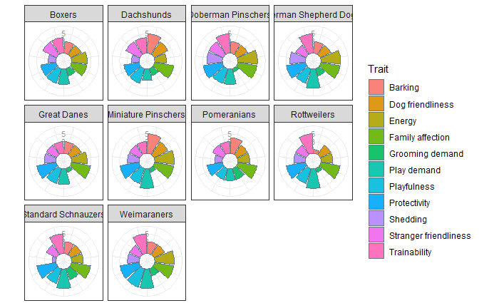

```r
ggplot(german_favs_long) +
  geom_col(aes(x = Trait, y = Value, fill = Trait),
    position = "dodge2",
    show.legend = TRUE,
    alpha = .9) +

  # Scale y axis so bars don't start in the center
  scale_y_continuous(
    limits = c(-2, 5),
    expand = c(0, 0),
    breaks = c(1, 3, 5) ) +


#Separate by breed
    facet_wrap(~Breed)+
  theme_bw()+


# Add y value texts
annotate(
    x = 0.5,
    y = 1.2,
    label = "1",
    geom = "text",
    size = 3) +

  annotate(
    x = 0.5,
    y = 3.2,
    label = "3",
    geom = "text",
    size = 3) +
  annotate(
    x = 0.5,
    y =5.2,
    label = "5",
    geom = "text",
    size = 3) +

# Scale y axis so bars don't start in the center
  scale_y_continuous(
    limits = c(-2, 6),
    expand = c(0, 0),
    breaks = c(1, 3, 5)  ) +

# Make it circular
  coord_polar()+

  #Remove axis titles
  theme(axis.text.x=element_blank(),
        axis.ticks.x=element_blank(),
        axis.title.x = element_blank(),
        axis.text.y=element_blank(),
        axis.ticks.y=element_blank(),
        axis.title.y = element_blank())
```

# Board games dataset

Download data from Github.

```r
game_ratings = readr::read_csv('https://raw.githubusercontent.com/rfordatascience/tidytuesday/master/data/2022/2022-01-25/ratings.csv')
game_details = readr::read_csv('https://raw.githubusercontent.com/rfordatascience/tidytuesday/master/data/2022/2022-01-25/details.csv')
```

Create a dataset joining some columns from ratings and details.

```r
games = left_join (
# select columns (id, name, average) from dataframe “game_ratings”
  select(game_ratings, id, name, average),

# select columns (id, boardgamecategory) from dataframe “details”
  select(game_details,id,boardgamecategory),

# variable that is the same in both dataframes
  by = "id")    %>%

# Edit categories names
  mutate(boardgamecategory = str_match_all(boardgamecategory,"\'([a-zA-Z\\s]+)\'"))%>%

# Unnest games with more than one category
  unnest(boardgamecategory) %>%

# Remove the description column of boardgamecategory
  mutate(boardgamecategory= (boardgamecategory[,1]))
```

Find 5 most popular game categories

```r
top_games <- games %>%
  group_by(boardgamecategory) %>%   #group by category
  summarize(n()) %>%                #add count by category
  top_n(5)                        #filter top 5
top_games
```

| boardgamecategory | n() |
| --- | --- |
| 'Card Game' | 6402 |
| 'Dice' | 1847 |
| 'Fantasy' | 2681 |
| 'Party Game' | 1968 |
| 'Wargame' | 3820 |

Filter games from the most popular categories

```r
games <- games %>%
  filter(boardgamecategory == top_games$boardgamecategory)
```

## Half-Eye Plot

https://cran.r-project.org/web/packages/ggdist/vignettes/slabinterval.html

Requires ggdist package.

```r
library(ggdist)
```

Plot

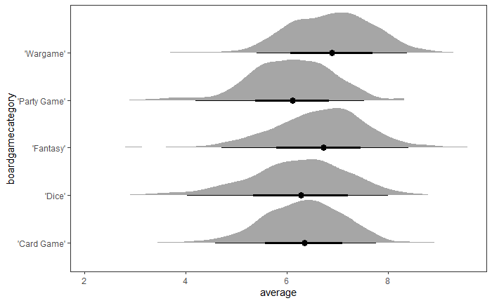

```r
ggplot(games, aes(x = average, y = boardgamecategory)) +

  stat_halfeye(slab_type="pdf") +  # PDF = probability density function. Can be replaced by histogram or CDF (cumulative density function)

  stat_pointinterval(.width = c(.5, .95)) +     #define the confidence intervals for the bars

  theme_test()
```

# Erasmus students mobility dataset

Download data from Github.

```r
erasmus <- readr::read_csv('https://raw.githubusercontent.com/rfordatascience/tidytuesday/master/data/2022/2022-03-08/erasmus.csv')
```

```r
erasmusmob = erasmus %>%

  #select columns of interest
  select(sending_country_code, receiving_country_code, participants, ) %>%

  # rename columns
  rename("from" = "sending_country_code",
         "to" = "receiving_country_code",
          "n" = "participants")%>%
  # group rows by from-to combinations
  group_by (from, to) %>%

  # sum up rows with same from-to combination
  summarise (sum = sum(n)) %>%

  # filter out cases of inland mobility
  filter(from != to) %>%

  # filter combinations with more than 100 participants
  filter(sum>100)
```

## Sankey diagram

```r
library(networkD3)
```

Create the nodes

```r
nodes <- data.frame(name=c(as.character(erasmusmob$from),
                           as.character(erasmusmob$to))
                    %>% unique())
```

Create IDs for country of origin and destination

```r
erasmusmob$IDfrom=match(erasmusmob$from, nodes$name)-1
erasmusmob$IDto=match(erasmusmob$to, nodes$name)-1
```

Sankey diagram

```r
sankeyNetwork(Links = erasmusmob,
              Nodes = nodes,
              Source = "IDfrom",
              Target = "IDto",
              Value = "sum",
              NodeID = "name",
              sinksRight=FALSE,
              #colourScale=ColourScal,
              nodeWidth=20,
              fontSize=13,
              nodePadding=7
             )
```

```
Links is a tbl_df. Converting to a plain data frame.
```

[interactive chart not shown]

Note: Sankey diagrams organize the targets based on the proximity to the origin. For keeping all targets on the right side, we must use an alluvial plot.

## Alluvial plot

```r
library(ggforce)
```

Prepare dataset with ggforce helper funtion.

```r
erasmusmob = erasmusmob  %>%
  gather_set_data(1:2) %>%
  arrange(x,from,desc(to))
```

Alluvial plot. x, id and y must remain the same, as they are created by ggforce helper function. Only thing to change is the value.

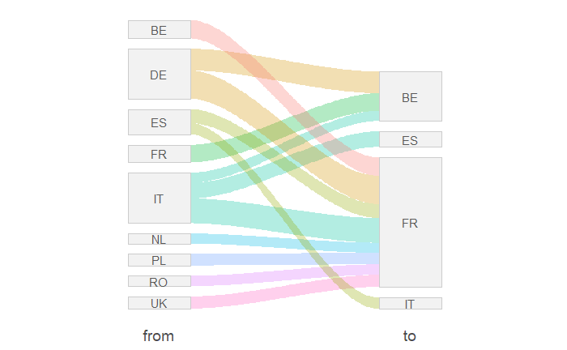

```r
ggplot(erasmusmob, aes(x = x, id = id, split = y, value = sum)) +
  geom_parallel_sets(aes(fill = from),        #color flow according to origin
                     alpha=0.3,axis.width = 0.25,
                     n=100,strength = 0.3) +  # n and strength change how curvy the flow is
  geom_parallel_sets_axes(axis.width = 0.25,  # add boxes for origin and target
                          fill = "gray95", color = "gray80") +
  geom_parallel_sets_labels(colour = 'gray35', size = 4, angle = 0) + #add text
  theme_minimal() +
  theme(legend.position = "none",            # removes legend
        panel.grid.major = element_blank(),  # removes lines
        panel.grid.minor = element_blank(),  # removes lines
        axis.text.y = element_blank(),       # removes y axis text
        axis.text.x = element_text(size = 14), # x axis font size
        axis.title.x  = element_blank())      # removes x axis title
```